# Propensity to Purchase Classification Modelling

Odomero Omokahfe; Sun Yufei

2023-01-19

# Loading packages required

```r
library(readr)
library(tidyverse)
library(MASS)
library(tree)
library(caret)
library(rpart)
library(rpart.plot)
library(rattle)
library(pROC)
library(here)
library(e1071)
library(xgboost)
```

# Introduction

The aim of this project is to build a classification model, using Google Analytics data on each visitor session on Google Merchandise Store, that predicts whether each session will result in the visitor performing an action to add an item to the cart.

The data was extracted from Google BigQuery kaggleworkshops.

```r
# Loading Data
google_store_data <- read_csv("data/google_store_analytics.csv")
```

```r
# Data Preview
google_store_data %>% glimpse()
```

```
## Rows: 25,914
## Columns: 19
## $ fullVisitorId      <chr> "843685434320284092", "353399298764494492", "353399…
## $ visitStartTime     <dbl> 1483314458, 1483328861, 1483328792, 1483328967, 148…
## $ date               <chr> "2017-01-01 00:00:00.000000 UTC", "2017-01-01 00:00…
## $ deviceCategory     <chr> "mobile", "mobile", "mobile", "mobile", "mobile", "…
## $ isMobile           <lgl> TRUE, TRUE, TRUE, TRUE, TRUE, TRUE, TRUE, TRUE, TRU…
## $ operatingSystem    <chr> "iOS", "iOS", "iOS", "iOS", "iOS", "iOS", "iOS", "i…
## $ browser            <chr> "Safari", "Safari", "Safari", "Safari", "Safari", "…
## $ country            <chr> "Saudi Arabia", "Saudi Arabia", "Saudi Arabia", "Sa…
## $ city               <chr> "Jeddah", "Riyadh", "Riyadh", "Riyadh", "Riyadh", "…
## $ trafficSource      <chr> "google", "google", "google", "google", "google", "…
## $ trafficMedium      <chr> "cpc", "cpc", "cpc", "cpc", "cpc", "cpc", "cpc", "c…
## $ trafficCampaign    <chr> "(not set)", "(not set)", "(not set)", "(not set)",…
## $ isFirstVisit       <dbl> 0, 0, 0, 0, 0, 1, 1, 1, 1, 1, 1, 1, 1, 1, 1, 1, 1, …
## $ totalVisits        <dbl> 1, 1, 1, 1, 1, 1, 1, 1, 1, 1, 1, 1, 1, 1, 1, 1, 1, …
## $ totalHits          <dbl> 1, 1, 1, 1, 1, 1, 1, 1, 1, 1, 1, 1, 1, 1, 1, 1, 1, …
## $ totalPageviews     <dbl> 1, 1, 1, 1, 1, 1, 1, 1, 1, 1, 1, 1, 1, 1, 1, 1, 1, …
## $ totalTimeOnSite    <dbl> 0, 0, 0, 0, 0, 0, 0, 0, 0, 0, 0, 0, 0, 0, 0, 0, 0, …
## $ productPagesViewed <dbl> 0, 0, 0, 0, 0, 0, 0, 0, 0, 0, 0, 0, 0, 0, 0, 0, 0, …
## $ addedToCart        <dbl> 0, 0, 0, 0, 0, 0, 0, 0, 0, 0, 0, 0, 0, 0, 0, 0, 0, …
```

See dataset schema below; **fullVisitorId**: The unique visitor ID. **visitStartTime**: The timestamp (expressed as POSIX time). **date**: The date of the session. **deviceCategory**: The type of device (Mobile, Tablet, Desktop). **isMobile**: If the user is on a mobile device, this value is true, otherwise false. **operatingSystem**: The operating system of the device (e.g., “Macintosh” or “Windows”). **browser**: The browser used (e.g., “Chrome” or “Firefox”). **country**: The country from which sessions originated, based on IP address. **city**: Users’ city, derived from their IP addresses or Geographical IDs **trafficSource**: The source of the traffic source. Could be the name of the search engine, the referring hostname, or a value of the utm_source URL parameter. **trafficMedium**: The medium of the traffic source. Could be “organic”, “cpc”, “referral”, or the value of the utm_medium URL parameter. **trafficCampaign**: The campaign value. Usually set by the utm_campaign URL parameter. **isFirstVisit**: 1 if this is the first visit made by the visitor, otherwise 0. **isBounce**: 1 if the visitor went to only one webpage and did not come back, otherwise 0. **totalVisits**: The total number of visits by the visitor across sessions. **totalHits**: The total number of interactions across sessions. **totalPageviews**: The total number of page views across sessions. **totalTimeOnSite**: The total time on site. **totalTransactions**: The total number of interactions across sessions. **productPagesViewed**: The number of product pages viewed in the session. **addedToCart**: 1 if the visitor added an item to the cart or made further downstream actions (checkout, transaction), otherwise 0 (if the visitor only browsed but never added an item to the cart).

**We will consider predicting probability of a visitor adding to cart during a session** **(`addedToCart`) given a set of characteristics.**

# Data Preprocessing and Analysis

**Let’s examine frequencies of the target variable:**

```r
table(google_store_data$addedToCart)
```

```
##
##     0     1
## 24211  1703
```

```r
table(google_store_data$addedToCart)/length(google_store_data$addedToCart)
```

```
##
##          0          1
## 0.93428263 0.06571737
```

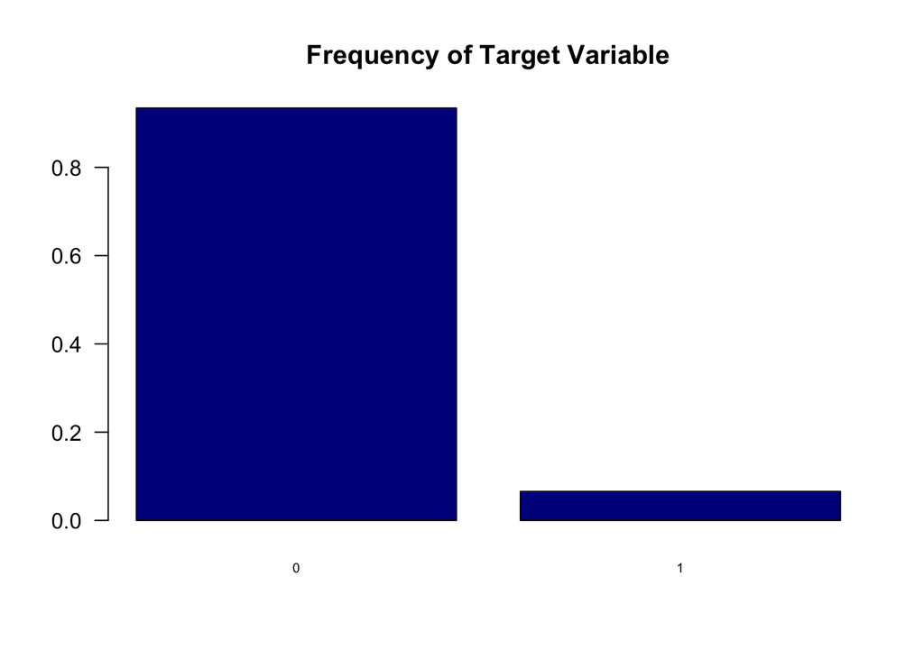

```r
barplot(table(google_store_data$addedToCart)/length(google_store_data$addedToCart),
        col = "darkblue",  # colors
        main = "Frequency of Target Variable",
        horiz = F,  # horizontal type of plot
        las = 1,    # labels always horizontally
        cex.names = 0.6)
```

About 93.43 % of observations did not add an item to cart.

**Let us also set the levels `1` as the first one.**

```r
google_store_data$addedToCart <- ifelse(
  google_store_data$addedToCart == 1, "Yes", "No")

google_store_data$addedToCart <- factor(google_store_data$addedToCart, levels = c("Yes", "No"))
table(google_store_data$addedToCart)
```

```
##
##   Yes    No
##  1703 24211
```

#### Transforming variables

```r
# Transforming qualitative variables

google_store_data$city[google_store_data$city == "not available in demo dataset"] <- "not set"

google_store_data_nominal <-
  sapply(google_store_data[, -1], is.character) %>%
  which() %>%
  names()

for (var in google_store_data_nominal) {
  if (var == "date") {
    next
  }
  google_store_data[[var]] <- as.factor(google_store_data[[var]])
}

google_store_data$isMobile <- as.factor(google_store_data$isMobile)
```

```r
# Transforming quantitative variables
google_store_data_quant <-
  sapply(google_store_data[, -1], is.double) %>%
  which() %>%
  names()

for (var in google_store_data_quant) {
  google_store_data[[var]] <- as.integer(google_store_data[[var]])
}

# Transforming date variable
google_store_data$date <- as.Date(google_store_data$date, "%Y-%m-%d")
```

#### Feature engineering

```r
# Create day and month columns from date
google_store_data <- google_store_data %>%
  dplyr::mutate(month = lubridate::month(date),
                day = lubridate::day(date))

# Transform into factors
for (var in c("month","day")) {
  google_store_data[[var]] <- as.factor(google_store_data[[var]])
}
```

**Let’s review the new structure of the dataset**

```r
glimpse(google_store_data)
```

```
## Rows: 25,914
## Columns: 21
## $ fullVisitorId      <chr> "843685434320284092", "353399298764494492", "353399…
## $ visitStartTime     <int> 1483314458, 1483328861, 1483328792, 1483328967, 148…
## $ date               <date> 2017-01-01, 2017-01-01, 2017-01-01, 2017-01-01, 20…
## $ deviceCategory     <fct> mobile, mobile, mobile, mobile, mobile, mobile, mob…
## $ isMobile           <fct> TRUE, TRUE, TRUE, TRUE, TRUE, TRUE, TRUE, TRUE, TRU…
## $ operatingSystem    <fct> iOS, iOS, iOS, iOS, iOS, iOS, iOS, iOS, iOS, iOS, i…
## $ browser            <fct> Safari, Safari, Safari, Safari, Safari, Safari, Saf…
## $ country            <fct> Saudi Arabia, Saudi Arabia, Saudi Arabia, Saudi Ara…
## $ city               <fct> Jeddah, Riyadh, Riyadh, Riyadh, Riyadh, Jeddah, Jed…
## $ trafficSource      <fct> google, google, google, google, google, google, goo…
## $ trafficMedium      <fct> cpc, cpc, cpc, cpc, cpc, cpc, cpc, cpc, cpc, cpc, c…
## $ trafficCampaign    <fct> (not set), (not set), (not set), (not set), (not se…
## $ isFirstVisit       <int> 0, 0, 0, 0, 0, 1, 1, 1, 1, 1, 1, 1, 1, 1, 1, 1, 1, …
## $ totalVisits        <int> 1, 1, 1, 1, 1, 1, 1, 1, 1, 1, 1, 1, 1, 1, 1, 1, 1, …
## $ totalHits          <int> 1, 1, 1, 1, 1, 1, 1, 1, 1, 1, 1, 1, 1, 1, 1, 1, 1, …
## $ totalPageviews     <int> 1, 1, 1, 1, 1, 1, 1, 1, 1, 1, 1, 1, 1, 1, 1, 1, 1, …
## $ totalTimeOnSite    <int> 0, 0, 0, 0, 0, 0, 0, 0, 0, 0, 0, 0, 0, 0, 0, 0, 0, …
## $ productPagesViewed <int> 0, 0, 0, 0, 0, 0, 0, 0, 0, 0, 0, 0, 0, 0, 0, 0, 0, …
## $ addedToCart        <fct> No, No, No, No, No, No, No, No, No, No, No, No, No,…
## $ month              <fct> 1, 1, 1, 1, 1, 1, 12, 1, 12, 3, 1, 1, 12, 1, 1, 12,…
## $ day                <fct> 1, 1, 1, 1, 1, 1, 26, 1, 28, 8, 1, 1, 25, 8, 1, 25,…
```

**Check for missing values**

```r
# Lets check if there are any missing values
any(is.na(google_store_data))
```

```
## [1] FALSE
```

**Descriptive Summary**

We will proceed to exclude fullVisitorId, date and totalVisits(1 visit per observation) from our models as they will have no contribution to the analysis.

```r
summary(google_store_data)
```

```
##  fullVisitorId      visitStartTime           date            deviceCategory
##  Length:25914       Min.   :1.470e+09   Min.   :2016-08-01   desktop: 8836
##  Class :character   1st Qu.:1.478e+09   1st Qu.:2016-10-27   mobile :14721
##  Mode  :character   Median :1.483e+09   Median :2016-12-28   tablet : 2357
##                     Mean   :1.483e+09   Mean   :2017-01-01
##                     3rd Qu.:1.489e+09   3rd Qu.:2017-03-10
##                     Max.   :1.496e+09   Max.   :2017-05-31
##
##   isMobile      operatingSystem               browser
##  FALSE: 8832   iOS      :13834   Chrome           :12555
##  TRUE :17082   Macintosh: 4103   Safari           :11615
##                Windows  : 3451   Safari (in-app)  :  926
##                Android  : 3237   Firefox          :  453
##                Chrome OS:  724   Internet Explorer:  137
##                Linux    :  559   Edge             :  100
##                (Other)  :    6   (Other)          :  128
##            country                 city        trafficSource   trafficMedium
##  United States :19146   not set      : 7996   (direct):11079   (none):11078
##  United Kingdom:  969   New York     : 2128   dfa     : 5130   cpc   : 9645
##  Canada        :  857   Mountain View: 1512   google  : 9705   cpm   : 5191
##  Australia     :  669   San Jose     :  989
##  India         :  531   London       :  891
##  Singapore     :  251   Chicago      :  842
##  (Other)       : 3491   (Other)      :11556
##                            trafficCampaign   isFirstVisit     totalVisits
##  (not set)                         :17538   Min.   :0.0000   Min.   :1
##  All Products                      :    4   1st Qu.:0.0000   1st Qu.:1
##  AW - Accessories                  : 3713   Median :1.0000   Median :1
##  AW - Apparel                      :   16   Mean   :0.6191   Mean   :1
##  AW - Dynamic Search Ads Whole Site: 4570   3rd Qu.:1.0000   3rd Qu.:1
##  AW - Electronics                  :   73   Max.   :1.0000   Max.   :1
##
##    totalHits       totalPageviews    totalTimeOnSite  productPagesViewed
##  Min.   :  1.000   Min.   :  0.000   Min.   :   0.0   Min.   : 0.0000
##  1st Qu.:  1.000   1st Qu.:  1.000   1st Qu.:   0.0   1st Qu.: 0.0000
##  Median :  2.000   Median :  2.000   Median :  18.0   Median : 0.0000
##  Mean   :  5.829   Mean   :  4.803   Mean   : 158.5   Mean   : 0.5454
##  3rd Qu.:  6.000   3rd Qu.:  5.000   3rd Qu.: 136.0   3rd Qu.: 0.0000
##  Max.   :227.000   Max.   :202.000   Max.   :9435.0   Max.   :50.0000
##
##  addedToCart     month           day
##  Yes: 1703   12     :3488   24     : 1016
##  No :24211   5      :3019   9      : 1013
##              1      :2975   10     : 1012
##              11     :2784   20     :  991
##              2      :2693   17     :  984
##              10     :2583   26     :  945
##              (Other):8372   (Other):19953
```

# Model Building and Evaluation

### Divide dataset into train, validation and test sample

```r
# Split dataset into 80% train and 20% test
set.seed(123456789)
train_obs <- createDataPartition(google_store_data$addedToCart,
                                    p = 0.8,
                                    list = FALSE)

data.train <- google_store_data[train_obs,]
google_store_data.test  <- google_store_data[-train_obs,]

# Split train data into 60% train and 40% validation
val_obs <- createDataPartition(data.train$addedToCart,
                                    p = 0.6,
                                    list = FALSE)
google_store_data.train <- data.train[val_obs,]
google_store_data.val  <- data.train[-val_obs,]
```

**Let’s view frequenncies of the datasets**

```r
# Train data
table(google_store_data.train$addedToCart)
```

```
##
##   Yes    No
##   818 11622
```

```r
table(google_store_data.train$addedToCart)/length(google_store_data.train$addedToCart)
```

```
##
##        Yes         No
## 0.06575563 0.93424437
```

```r
# Validation data
table(google_store_data.val$addedToCart)
```

```
##
##  Yes   No
##  545 7747
```

```r
table(google_store_data.val$addedToCart)/length(google_store_data.val$addedToCart)
```

```
##
##      Yes       No
## 0.065726 0.934274
```

```r
# Test data
table(google_store_data.test$addedToCart)
```

```
##
##  Yes   No
##  340 4842
```

```r
table(google_store_data.test$addedToCart)/length(google_store_data.test$addedToCart)
```

```
##
##        Yes         No
## 0.06561173 0.93438827
```

**Same frequency was maintained across 3 datasets**

### Decision Tree Modelling

#### Define the formula of the model with all meaningful predictors

```r
dt.model.1.formula <- addedToCart ~ visitStartTime + deviceCategory +
  isMobile + operatingSystem + browser + country + city + trafficSource +
  trafficMedium + trafficCampaign + isFirstVisit + totalHits + totalPageviews +
  totalTimeOnSite + productPagesViewed + month + day
```

#### Building Tree 1 with default parameters

```r
google_store_data.tree.1 <-
  rpart(dt.model.1.formula,
        data = google_store_data.train,
        method = "class") # type of the tree: classification

google_store_data.tree.1
```

```
## n= 12440
##
## node), split, n, loss, yval, (yprob)
##       * denotes terminal node
##
##   1) root 12440 818 No (0.06575563 0.93424437)
##     2) totalHits>=12.5 1493 621 No (0.41594106 0.58405894)
##       4) totalHits>=23.5 556 216 Yes (0.61151079 0.38848921)
##         8) city=(not set),Ann Arbor,Athens,Atlanta,Boulder,Bucharest,Cambridge,Charlotte,Chicago,Dallas,Denver,Dubai,El Paso,Fremont,Houston,Irvine,Kirkland,Leeds,Lehi,London,Los Angeles,Madison,Mexico City,Mississauga,Montreal,Mountain View,Mumbai,New York,not set,Ottawa,Palo Alto,Paris,Philadel…
##          16) totalHits>=46.5 135  20 Yes (0.85185185 0.14814815) *
##          17) totalHits< 46.5 376 156 Yes (0.58510638 0.41489362)
##            34) city=(not set),Athens,Boulder,Charlotte,Dallas,Denver,Dubai,El Paso,Houston,Irvine,Leeds,Lehi,Los Angeles,Madison,Mexico City,Mississauga,Montreal,Ottawa,Philadelphia,Portland,Sacramento,San Diego,San Jose,Santa Clara,Sao Paulo,Sherbrooke,Shinjuku,Sydney,Tel Aviv-Yafo 61   7 Yes (0…
##            35) city=Ann Arbor,Atlanta,Bucharest,Chicago,Fremont,Kirkland,London,Mountain View,New York,not set,Palo Alto,Paris,San Bruno,San Francisco,San Mateo,Seattle,Sunnyvale,Toronto,Washington 315 149 Yes (0.52698413 0.47301587)
##              70) day=2,3,4,5,6,7,9,10,15,16,17,20,26,28,29,30 179  62 Yes (0.65363128 0.34636872)
##               140) productPagesViewed>=0.5 163  49 Yes (0.69938650 0.30061350) *
##               141) productPagesViewed< 0.5 16   3 No (0.18750000 0.81250000) *
##              71) day=1,8,11,12,13,14,18,19,21,22,23,24,25,27,31 136  49 No (0.36029412 0.63970588) *
##         9) city=Austin,Bangkok,Bengaluru,Boston,Buenos Aires,Chennai,Colombo,Fresno,Hanoi,Hong Kong,Istanbul,Jakarta,Jersey City,Madrid,Melbourne,Milpitas,Minato,Oakland,Omaha,Osaka,Salem,San Antonio,Seoul,Singapore,Warsaw 45   5 No (0.11111111 0.88888889) *
##       5) totalHits< 23.5 937 281 No (0.29989328 0.70010672)
##        10) city=Amsterdam,Bangkok,Bucharest,Buenos Aires,Cambridge,Charlotte,Chennai,Cupertino,El Paso,Hyderabad,Kuala Lumpur,Melbourne,Mexico City,Milan,Mississauga,Montreal,Moscow,New York,Palo Alto,Paris,Perth,Philadelphia,Pittsburgh,Prague,Quezon City,Redwood City,San Bruno,San Diego,Singapor…
##          20) day=1,2,3,4,5,6,7,9,10,11,14,15,18,19,23,24,25,26,27,28,30 125  36 Yes (0.71200000 0.28800000) *
##          21) day=8,12,13,16,17,20,21,22,29,31 59  23 No (0.38983051 0.61016949) *
##        11) city=(not set),Ann Arbor,Atlanta,Austin,Barcelona,Boston,Boulder,Brisbane,Charlottesville,Chicago,Cluj-Napoca,Columbus,Dallas,Deva,Druid Hills,Dubai,Dublin,Fremont,Hanoi,Hong Kong,Houston,Irvine,Istanbul,Jakarta,Kirkland,London,Los Angeles,Lyon,Makati,Manila,Medellin,Miami,Milpitas,Min…
##     3) totalHits< 12.5 10947 197 No (0.01799580 0.98200420) *
```

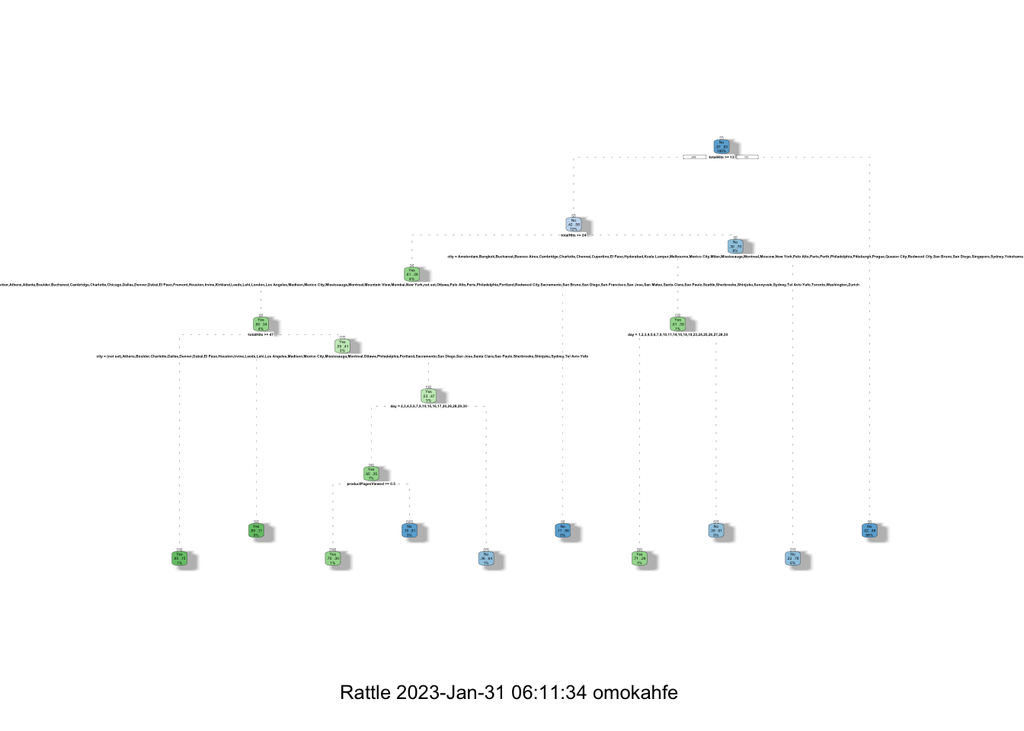

```r
fancyRpartPlot(google_store_data.tree.1)
```

#### Building Tree 2 with minsplit = 1000 and minbucket = 400

```r
google_store_data.tree.2 <-
  rpart(dt.model.1.formula,
        data = google_store_data.train,
        method = "class",
        minsplit = 1000,
        minbucket = 400,
        maxdepth = 30 )

google_store_data.tree.2
```

```
## n= 12440
##
## node), split, n, loss, yval, (yprob)
##       * denotes terminal node
##
## 1) root 12440 818 No (0.06575563 0.93424437)
##   2) totalHits>=12.5 1493 621 No (0.41594106 0.58405894)
##     4) totalHits>=23.5 556 216 Yes (0.61151079 0.38848921) *
##     5) totalHits< 23.5 937 281 No (0.29989328 0.70010672) *
##   3) totalHits< 12.5 10947 197 No (0.01799580 0.98200420) *
```

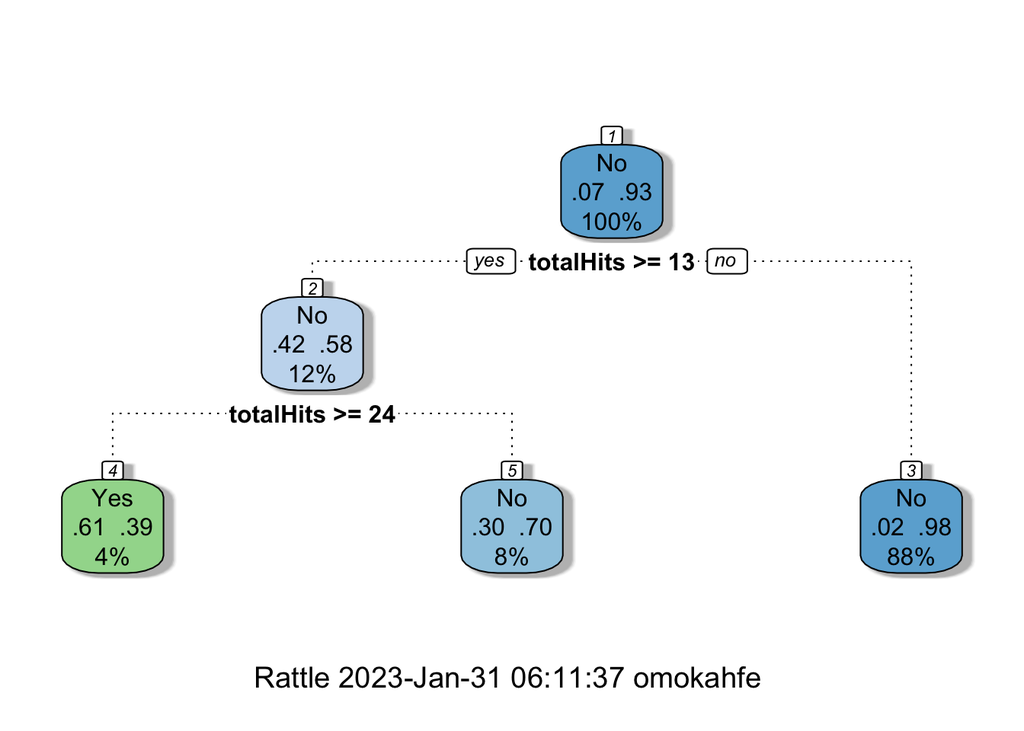

```r
fancyRpartPlot(google_store_data.tree.2)
```

#### Cross validation using different values of cp coefficient

```r
control_1 <- trainControl(method = "cv",
                   number = 10,
                   classProbs = TRUE,
                   summaryFunction = twoClassSummary)
```

#### Building Tree 3 with cross validation of cp

```r
modelLookup("rpart")
```

```
##   model parameter                label forReg forClass probModel
## 1 rpart        cp Complexity Parameter   TRUE     TRUE      TRUE
```

```r
cp.grid <- expand.grid(cp = seq(0, 0.01, 0.001))

set.seed(123456789)
google_store_data.tree.3 <-
  train(dt.model.1.formula,
        data = google_store_data.train,
        method = "rpart",
        metric = "ROC",
        trControl = control_1,
        tuneGrid  = cp.grid)

google_store_data.tree.3
```

```
## CART
##
## 12440 samples
##    17 predictor
##     2 classes: 'Yes', 'No'
##
## No pre-processing
## Resampling: Cross-Validated (10 fold)
## Summary of sample sizes: 11197, 11195, 11196, 11196, 11196, 11196, ...
## Resampling results across tuning parameters:
##
##   cp     ROC        Sens       Spec
##   0.000  0.9177086  0.4733062  0.9720354
##   0.001  0.9109779  0.4586420  0.9753051
##   0.002  0.8669209  0.4415236  0.9791772
##   0.003  0.8498388  0.4365854  0.9813281
##   0.004  0.8499388  0.4207167  0.9824467
##   0.005  0.8515098  0.4255796  0.9821885
##   0.006  0.8525423  0.4207016  0.9818447
##   0.007  0.8535414  0.4072870  0.9818446
##   0.008  0.8531277  0.4133243  0.9824472
##   0.009  0.8523811  0.3925926  0.9827913
##   0.010  0.8523586  0.4035682  0.9819307
##
## ROC was used to select the optimal model using the largest value.
## The final value used for the model was cp = 0.
```

#### Let’s evaluate the models using GINI coefficient

```r
train.tree1.pred <- predict(google_store_data.tree.1, google_store_data.train)
train.tree1.ROC  <- roc(
  as.numeric(google_store_data.train$addedToCart == "Yes"), train.tree1.pred[, 1])
train.tree2.pred <- predict(google_store_data.tree.2, google_store_data.train)
train.tree2.ROC  <- roc(
  as.numeric(google_store_data.train$addedToCart == "Yes"), train.tree2.pred[, 1])
train.tree3.pred <- predict(google_store_data.tree.3, google_store_data.train)
train.tree3.ROC  <- roc(
  as.numeric(google_store_data.train$addedToCart == "Yes"), as.numeric(train.tree3.pred))
```

#### Model Evaluation on train data

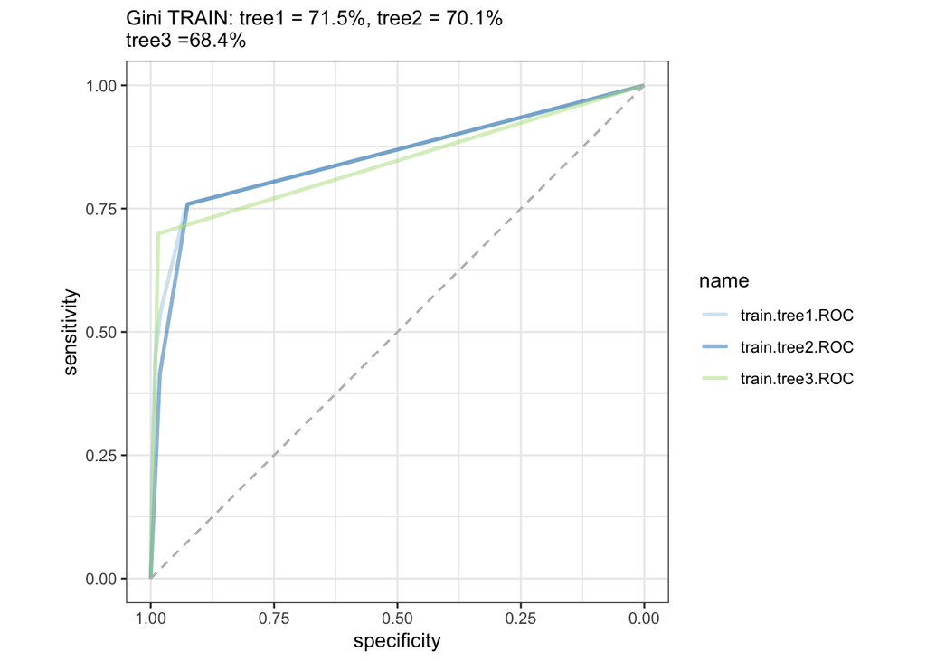

```r
# Model evaluation on train data
list(
  train.tree1.ROC  = train.tree1.ROC,
  train.tree2.ROC = train.tree2.ROC,
  train.tree3.ROC = train.tree3.ROC
) %>%
  pROC::ggroc(alpha = 0.5, linetype = 1, size = 1) +
  geom_segment(aes(x = 1, xend = 0, y = 0, yend = 1),
               color = "grey",
               linetype = "dashed") +
  labs(subtitle = paste0("Gini TRAIN: ",
                         "tree1 = ",
                         round(100*(2 * auc(train.tree1.ROC) - 1), 1), "%, ",
                         "tree2 = ",
                         round(100*(2 * auc(train.tree2.ROC) - 1), 1), "% ",
                         "\ntree3 =",
                         round(100*(2 * auc(train.tree3.ROC) - 1), 1), "% ")) +
  theme_bw() + coord_fixed() +
  scale_color_brewer(palette = "Paired")
```

### Building Tree 4 with large trees and pruning

```r
google_store_data.tree.4 <-
  rpart(dt.model.1.formula,
        data = google_store_data.train,
        method = "class",
        minsplit = 320, # ~ 2% of the training set
        minbucket = 160, # ~ 1% of the training set
        maxdepth = 30, # default
        cp = -1)

google_store_data.tree.4
```

```
## n= 12440
##
## node), split, n, loss, yval, (yprob)
##       * denotes terminal node
##
##   1) root 12440 818 No (0.0657556270 0.9342443730)
##     2) totalHits>=12.5 1493 621 No (0.4159410583 0.5840589417)
##       4) totalHits>=23.5 556 216 Yes (0.6115107914 0.3884892086)
##         8) totalHits>=41.5 193  40 Yes (0.7927461140 0.2072538860) *
##         9) totalHits< 41.5 363 176 Yes (0.5151515152 0.4848484848)
##          18) day=2,3,4,5,6,9,10,12,15,17,20,25,26,28,30,31 197  73 Yes (0.6294416244 0.3705583756) *
##          19) day=1,7,8,11,13,14,16,18,19,21,22,23,24,27,29 166  63 No (0.3795180723 0.6204819277) *
##       5) totalHits< 23.5 937 281 No (0.2998932764 0.7001067236)
##        10) city=Amsterdam,Bangkok,Bucharest,Buenos Aires,Cambridge,Charlotte,Chennai,Cupertino,El Paso,Hyderabad,Kuala Lumpur,Melbourne,Mexico City,Milan,Mississauga,Montreal,Moscow,New York,Palo Alto,Paris,Perth,Philadelphia,Pittsburgh,Prague,Quezon City,Redwood City,San Bruno,San Diego,Singapor…
##        11) city=(not set),Ann Arbor,Atlanta,Austin,Barcelona,Boston,Boulder,Brisbane,Charlottesville,Chicago,Cluj-Napoca,Columbus,Dallas,Deva,Druid Hills,Dubai,Dublin,Fremont,Hanoi,Hong Kong,Houston,Irvine,Istanbul,Jakarta,Kirkland,London,Los Angeles,Lyon,Makati,Manila,Medellin,Miami,Milpitas,Min…
##          22) productPagesViewed>=0.5 557 157 No (0.2818671454 0.7181328546)
##            44) productPagesViewed< 2.5 312 111 No (0.3557692308 0.6442307692) *
##            45) productPagesViewed>=2.5 245  46 No (0.1877551020 0.8122448980) *
##          23) productPagesViewed< 0.5 196  12 No (0.0612244898 0.9387755102) *
##     3) totalHits< 12.5 10947 197 No (0.0179957979 0.9820042021)
##       6) productPagesViewed>=0.5 1097 163 No (0.1485870556 0.8514129444)
##        12) city=(not set),Ann Arbor,Atlanta,Austin,Belgrade,Bucharest,Budapest,Charlotte,Cluj-Napoca,Cordoba,Cupertino,Farmington Hills,Kiev,Kuala Lumpur,London,Miami,Minato,Minneapolis,New Delhi,New York,Oviedo,Philadelphia,Quebec City,San Bruno,San Mateo,Tigard,Timisoara 214  66 No (0.308411215…
##        13) city=Alba Iulia,Amsterdam,Anaheim,Auckland,Bangkok,Barcelona,Berlin,Bogota,Boston,Boulder,Brisbane,Brussels,Chennai,Chicago,Colombo,Columbus,Council Bluffs,Dallas,Detroit,Dubai,Dublin,Egham,Fremont,Fresno,Hamburg,Hong Kong,Houston,Hyderabad,Indianapolis,Istanbul,Jakarta,Jeddah,Jersey C…
##          26) totalHits>=5.5 677  97 No (0.1432791728 0.8567208272)
##            52) day=4,5,6,7,8,13,14,16,20,21,22,26,27,28,29,30,31 363  73 No (0.2011019284 0.7988980716)
##             104) totalHits>=8.5 190  49 No (0.2578947368 0.7421052632) *
##             105) totalHits< 8.5 173  24 No (0.1387283237 0.8612716763) *
##            53) day=1,2,3,9,10,11,12,15,17,18,19,23,24,25 314  24 No (0.0764331210 0.9235668790) *
##          27) totalHits< 5.5 206   0 No (0.0000000000 1.0000000000) *
##       7) productPagesViewed< 0.5 9850  34 No (0.0034517766 0.9965482234)
##        14) totalTimeOnSite>=188.5 896  24 No (0.0267857143 0.9732142857)
##          28) city=Austin,Brisbane,Dallas,Denver,London,Los Angeles,Madrid,Nashville,New York,San Francisco,Seattle 178  16 No (0.0898876404 0.9101123596) *
##          29) city=(not set),Ahmedabad,Amsterdam,Anaheim,Ann Arbor,Atlanta,Bangkok,Bengaluru,Berkeley,Berlin,Bogota,Boulder,Brampton,Bucharest,Budapest,Calgary,Cambridge,Canterbury,Cebu City,Charlotte,Chennai,Chicago,Council Bluffs,Cupertino,Detroit,Dubai,Dublin,Egham,Evanston,Faisalabad,Fremont,G…
##            58) day=4,7,11,14,15,19,25,27 184   8 No (0.0434782609 0.9565217391) *
##            59) day=1,2,3,5,6,8,9,10,12,13,16,17,18,20,21,22,23,24,26,28,29,30,31 534   0 No (0.0000000000 1.0000000000) *
##        15) totalTimeOnSite< 188.5 8954  10 No (0.0011168193 0.9988831807)
##          30) city=Austin,Dublin,Houston,Nashville,Philadelphia,San Jose,Sunnyvale 873   8 No (0.0091638030 0.9908361970)
##            60) totalHits>=3.5 164   8 No (0.0487804878 0.9512195122) *
##            61) totalHits< 3.5 709   0 No (0.0000000000 1.0000000000) *
##          31) city=(not set),Aalen,Abu Dhabi,Ahmedabad,Akron,Amberg,Amersfoort,Amsterdam,Ankara,Ann Arbor,Arnhem,Ashburn,Athens,Atlanta,Auckland,Avon,Bandung,Bangkok,Barcelona,Beijing,Belo Horizonte,Bengaluru,Berlin,Bien Hoa,Boardman,Bogota,Boston,Bothell,Boulder,Brampton,Brasilia,Bratislava,Brest…
##            62) day=6,10 601   2 No (0.0033277870 0.9966722130)
##             124) city=Chicago,New York,San Diego,San Francisco,San Mateo,Santa Clara,Sao Paulo,Seattle,Seoul,Shinjuku,Singapore,Sydney,Tel Aviv-Yafo,Toronto,Vancouver,Vienna,Warsaw,Washington,Waterloo,Yokohama,Zurich 161   2 No (0.0124223602 0.9875776398) *
##             125) city=(not set),Amsterdam,Ankara,Ann Arbor,Athens,Atlanta,Auckland,Bangkok,Barcelona,Bengaluru,Berlin,Boston,Boulder,Brisbane,Bucharest,Charlotte,Chennai,Colombo,Columbus,Cupertino,Dallas,Detroit,Druid Hills,Edmonton,Fremont,Gothenburg,Guadalajara,Hong Kong,Hyderabad,Irvine,Istanb…
##            63) day=1,2,3,4,5,7,8,9,11,12,13,14,15,16,17,18,19,20,21,22,23,24,25,26,27,28,29,30,31 7480   0 No (0.0000000000 1.0000000000) *
```

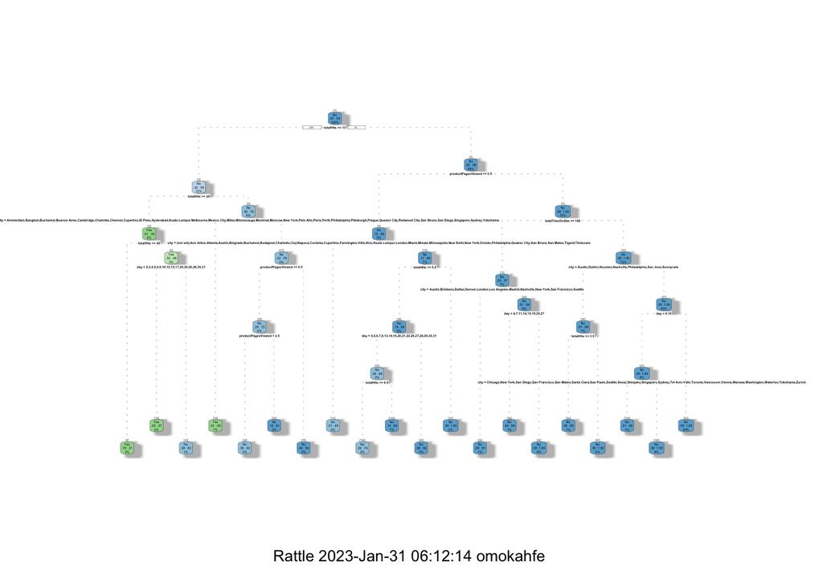

```r
fancyRpartPlot(google_store_data.tree.4)
```

#### Building Tree 4p with pruning of large trees

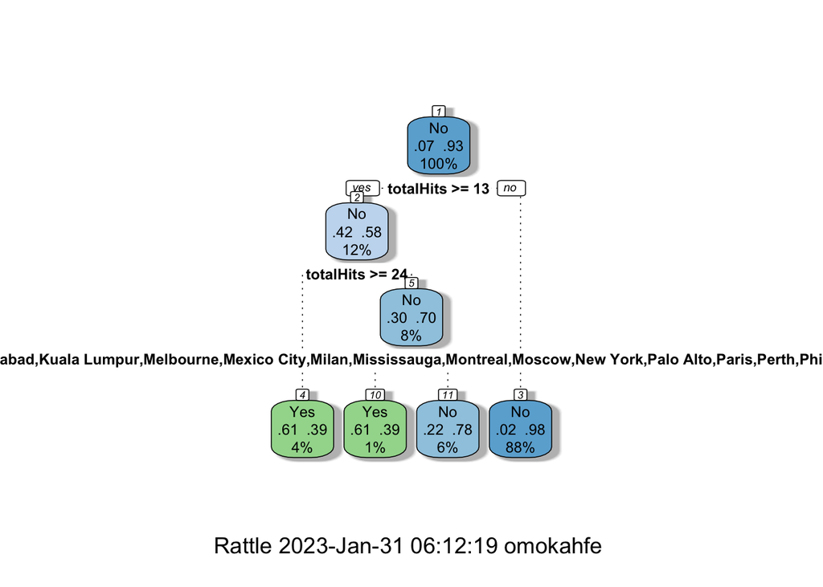

```r
opt <- which.min(google_store_data.tree.4$cptable[, "xerror"])
cp <- google_store_data.tree.4$cptable[opt, "CP"]

google_store_data.tree.4p <-
  prune(google_store_data.tree.4, cp = cp)

fancyRpartPlot(google_store_data.tree.4p)
```

#### Model Evaluation on train data

```r
train.tree4.pred <- predict(google_store_data.tree.4,
                            google_store_data.train)
train.tree4.ROC  <- roc(
  as.numeric(google_store_data.train$addedToCart == "Yes"), train.tree4.pred[, 1])
train.tree4p.pred <- predict(google_store_data.tree.4p,
                            google_store_data.train)
train.tree4p.ROC  <- roc(
  as.numeric(google_store_data.train$addedToCart == "Yes"), train.tree4p.pred[, 1])
```

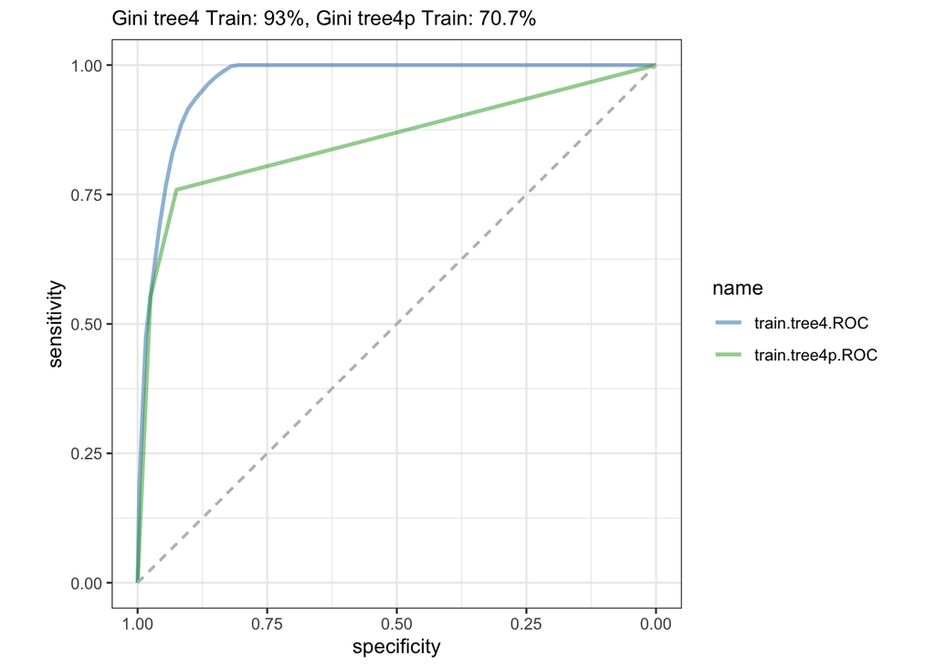

```r
# Model evaluation on train data
list(
  train.tree4.ROC  = train.tree4.ROC,
  train.tree4p.ROC = train.tree4p.ROC
) %>%
  pROC::ggroc(alpha = 0.5, linetype = 1, size = 1) +
  geom_segment(aes(x = 1, xend = 0, y = 0, yend = 1),
               color = "grey",
               linetype = "dashed") +
  labs(subtitle = paste0("Gini tree4 Train: ",
                         round(100*(2 * auc(train.tree4.ROC) - 1), 1), "%, ",
                         "Gini tree4p Train: ",
                         round(100*(2 * auc(train.tree4p.ROC) - 1), 1), "% ")) +
  theme_bw() + coord_fixed() +
  # scale_color_brewer(palette = "Paired") +
  scale_color_manual(values = RColorBrewer::brewer.pal(n = 4,
                                                       name = "Paired")[c(2, 4)])
```

**The larger tree seems to have a more higher GINI index of 93% but its possible there might be some overfitting**

#### Let’s look at variable importance using Tree 4 with highest AUC

```r
tree.4.importance <- google_store_data.tree.4$variable.importance
tree.4.importance
```

```
##          totalHits     totalPageviews productPagesViewed    totalTimeOnSite
##       5.183430e+02       4.211092e+02       2.854631e+02       1.158014e+02
##               city                day            country              month
##       7.248260e+01       1.806095e+01       1.613733e+01       1.300283e+00
##            browser    operatingSystem     visitStartTime       isFirstVisit
##       1.043838e+00       7.457558e-01       4.453816e-01       3.865076e-01
##    trafficCampaign
##       2.811843e-03
```

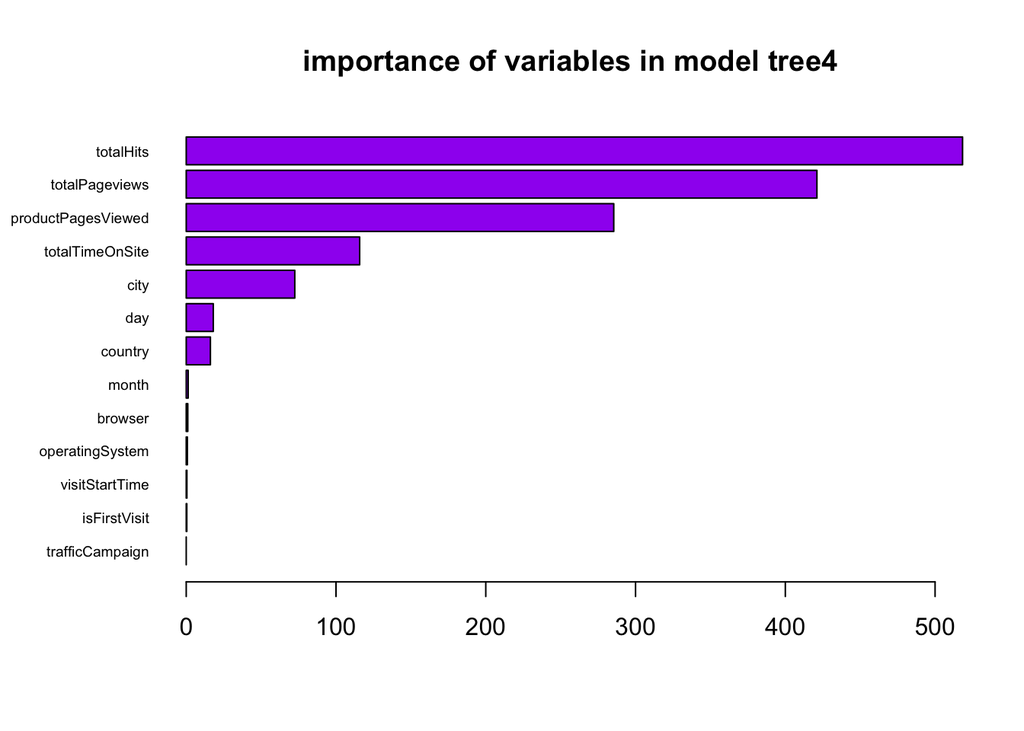

```r
par(mar = c(5.1, 6.1, 4.1, 2.1))
barplot(rev(tree.4.importance), # vactor
        col = "purple",  # colors
        main = "importance of variables in model tree4",
        horiz = T,  # horizontal type of plot
        las = 1,    # labels always horizontally
        cex.names = 0.6)
```

```r
(tree.4.importance.2 <- varImp(google_store_data.tree.4))
```

```
##                         Overall
## city               152.60341003
## day                 60.96905010
## isFirstVisit         0.02688986
## month               37.86758076
## operatingSystem      0.15384302
## productPagesViewed 524.85379883
## totalHits          558.46571981
## totalPageviews     444.37995181
## totalTimeOnSite    286.86675071
## visitStartTime      27.63351368
## deviceCategory       0.00000000
## isMobile             0.00000000
## browser              0.00000000
## country              0.00000000
## trafficSource        0.00000000
## trafficMedium        0.00000000
## trafficCampaign      0.00000000
```

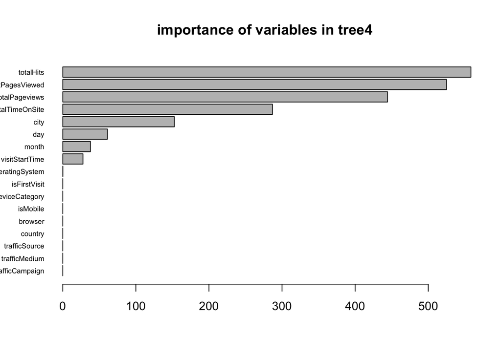

```r
tree.4.importance.2 <- tree.4.importance.2 %>%
  rownames_to_column("variable") %>%
  arrange(desc(Overall))

barplot(rev(tree.4.importance.2$Overall),
        names.arg = rev(tree.4.importance.2$variable),
        col = "grey",  # colors
        main = "importance of variables in tree4",
        horiz = T,  # horizontal type of plot
        las = 1,    # labels always horizontally
        cex.names = 0.6)
```

**Let us examine top 10 variables for both criteria**

```r
var_Imp <- intersect(tree.4.importance.2$variable[1:11],
          names(tree.4.importance)[1:11])
var_Imp
```

```
## [1] "totalHits"          "productPagesViewed" "totalPageviews"
## [4] "totalTimeOnSite"    "city"               "day"
## [7] "month"              "visitStartTime"     "operatingSystem"
```

```r
dt.model.2.formula <- addedToCart ~ operatingSystem +  city + visitStartTime +totalHits + totalPageviews + totalTimeOnSite + productPagesViewed + month + day
```

### Let’s build Tree 5 using important variables

```r
google_store_data.tree.5 <-
  rpart(dt.model.2.formula,
        data = google_store_data.train,
        method = "class",
        minsplit = 80,
        minbucket = 30,
        maxdepth = 20 )

google_store_data.tree.5
```

```
## n= 12440
##
## node), split, n, loss, yval, (yprob)
##       * denotes terminal node
##
##  1) root 12440 818 No (0.06575563 0.93424437)
##    2) totalHits>=12.5 1493 621 No (0.41594106 0.58405894)
##      4) totalHits>=23.5 556 216 Yes (0.61151079 0.38848921)
##        8) city=(not set),Ann Arbor,Athens,Atlanta,Boulder,Bucharest,Cambridge,Charlotte,Chicago,Dallas,Denver,Dubai,El Paso,Fremont,Houston,Irvine,Kirkland,Leeds,Lehi,London,Los Angeles,Madison,Mexico City,Mississauga,Montreal,Mountain View,Mumbai,New York,not set,Ottawa,Palo Alto,Paris,Philadelp…
##         16) totalHits>=46.5 135  20 Yes (0.85185185 0.14814815) *
##         17) totalHits< 46.5 376 156 Yes (0.58510638 0.41489362)
##           34) city=(not set),Athens,Boulder,Charlotte,Dallas,Denver,Dubai,El Paso,Houston,Irvine,Leeds,Lehi,Los Angeles,Madison,Mexico City,Mississauga,Montreal,Ottawa,Philadelphia,Portland,Sacramento,San Diego,San Jose,Santa Clara,Sao Paulo,Sherbrooke,Shinjuku,Sydney,Tel Aviv-Yafo 61   7 Yes (0.…
##           35) city=Ann Arbor,Atlanta,Bucharest,Chicago,Fremont,Kirkland,London,Mountain View,New York,not set,Palo Alto,Paris,San Bruno,San Francisco,San Mateo,Seattle,Sunnyvale,Toronto,Washington 315 149 Yes (0.52698413 0.47301587)
##             70) day=2,3,4,5,6,7,9,10,15,16,17,20,26,28,29,30 179  62 Yes (0.65363128 0.34636872) *
##             71) day=1,8,11,12,13,14,18,19,21,22,23,24,25,27,31 136  49 No (0.36029412 0.63970588) *
##        9) city=Austin,Bangkok,Bengaluru,Boston,Buenos Aires,Chennai,Colombo,Fresno,Hanoi,Hong Kong,Istanbul,Jakarta,Jersey City,Madrid,Melbourne,Milpitas,Minato,Oakland,Omaha,Osaka,Salem,San Antonio,Seoul,Singapore,Warsaw 45   5 No (0.11111111 0.88888889) *
##      5) totalHits< 23.5 937 281 No (0.29989328 0.70010672)
##       10) city=Amsterdam,Bangkok,Bucharest,Buenos Aires,Cambridge,Charlotte,Chennai,Cupertino,El Paso,Hyderabad,Kuala Lumpur,Melbourne,Mexico City,Milan,Mississauga,Montreal,Moscow,New York,Palo Alto,Paris,Perth,Philadelphia,Pittsburgh,Prague,Quezon City,Redwood City,San Bruno,San Diego,Singapore…
##         20) day=1,2,3,4,5,6,7,9,10,11,14,15,18,19,23,24,25,26,27,28,30 125  36 Yes (0.71200000 0.28800000) *
##         21) day=8,12,13,16,17,20,21,22,29,31 59  23 No (0.38983051 0.61016949) *
##       11) city=(not set),Ann Arbor,Atlanta,Austin,Barcelona,Boston,Boulder,Brisbane,Charlottesville,Chicago,Cluj-Napoca,Columbus,Dallas,Deva,Druid Hills,Dubai,Dublin,Fremont,Hanoi,Hong Kong,Houston,Irvine,Istanbul,Jakarta,Kirkland,London,Los Angeles,Lyon,Makati,Manila,Medellin,Miami,Milpitas,Mina…
##    3) totalHits< 12.5 10947 197 No (0.01799580 0.98200420) *
```

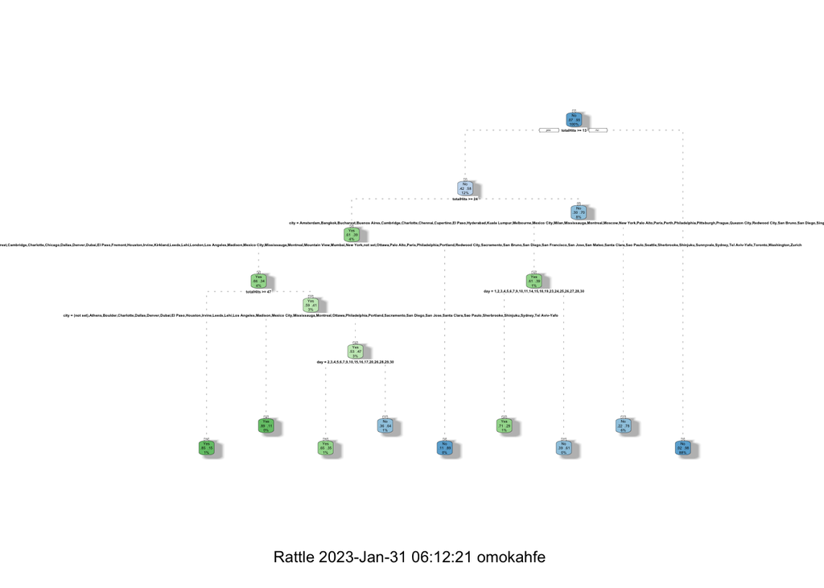

```r
fancyRpartPlot(google_store_data.tree.5)
```

```r
train.tree5.pred <- predict(google_store_data.tree.5,
                            google_store_data.train)
train.tree5.ROC  <- roc(
  as.numeric(google_store_data.train$addedToCart == "Yes"), train.tree5.pred[, 1])
cat("Gini train = ", 2 * train.tree5.ROC$auc - 1, "\n", sep = "")
```

```
## Gini train = 0.7145967
```

### Model evaluation on validation data

```r
val.tree1.pred <- predict(google_store_data.tree.1, google_store_data.val)
val.tree1.ROC  <- roc(
  as.numeric(google_store_data.val$addedToCart == "Yes"), val.tree1.pred[, 1])
val.tree2.pred <- predict(google_store_data.tree.2, google_store_data.val)
val.tree2.ROC  <- roc(
  as.numeric(google_store_data.val$addedToCart == "Yes"), val.tree2.pred[, 1])
val.tree3.pred <- predict(google_store_data.tree.3, google_store_data.val)
val.tree3.ROC  <- roc(
  as.numeric(google_store_data.val$addedToCart == "Yes"), as.numeric(val.tree3.pred))
val.tree4.pred <- predict(google_store_data.tree.4, google_store_data.val)
val.tree4.ROC  <- roc(
  as.numeric(google_store_data.val$addedToCart == "Yes"), val.tree4.pred[, 1])
val.tree4p.pred <- predict(google_store_data.tree.4p, google_store_data.val)
val.tree4p.ROC  <- roc(
  as.numeric(google_store_data.val$addedToCart == "Yes"), val.tree4p.pred[, 1])
val.tree5.pred <- predict(google_store_data.tree.5, google_store_data.val)
val.tree5.ROC  <- roc(
  as.numeric(google_store_data.val$addedToCart == "Yes"), val.tree5.pred[, 1])
```

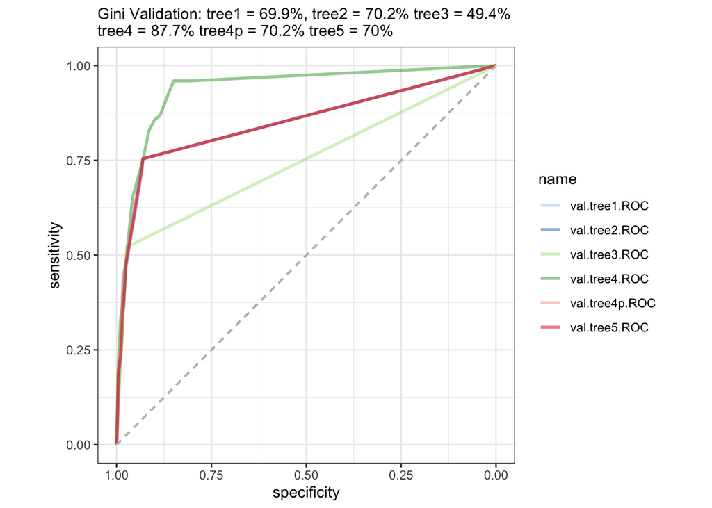

```r
list(
  val.tree1.ROC  = val.tree1.ROC,
  val.tree2.ROC = val.tree2.ROC,
  val.tree3.ROC = val.tree3.ROC,
  val.tree4.ROC = val.tree4.ROC,
  val.tree4p.ROC = val.tree4p.ROC,
  val.tree5.ROC = val.tree5.ROC
) %>%
  pROC::ggroc(alpha = 0.5, linetype = 1, size = 1) +
  geom_segment(aes(x = 1, xend = 0, y = 0, yend = 1),
               color = "grey",
               linetype = "dashed") +
  labs(subtitle = paste0("Gini Validation: ",
                         "tree1 = ",
                         round(100*(2 * auc(val.tree1.ROC) - 1), 1), "%, ",
                         "tree2 = ",
                         round(100*(2 * auc(val.tree2.ROC) - 1), 1), "% ",
                         "tree3 = ",
                         round(100*(2 * auc(val.tree3.ROC) - 1), 1), "% ",
                         "\ntree4 = ",
                         round(100*(2 * auc(val.tree4.ROC) - 1), 1), "% ",
                         "tree4p = ",
                         round(100*(2 * auc(val.tree4p.ROC) - 1), 1), "% ",
                         "tree5 = ",
                         round(100*(2 * auc(val.tree5.ROC) - 1), 1), "% ")) +
  theme_bw() + coord_fixed() +
  scale_color_brewer(palette = "Paired")
```

## XGBoost Modelling

```r
dt.model.1.formula <- addedToCart ~ visitStartTime + deviceCategory +
  isMobile + operatingSystem + browser + country + city + trafficSource +
  trafficMedium + trafficCampaign + isFirstVisit + totalHits + totalPageviews +
  totalTimeOnSite + productPagesViewed + month + day
```

**Balancing the data**

```r
google_store_data.train <-
  ROSE::ovun.sample(formula = dt.model.1.formula,
                    data = google_store_data[train_obs,],
                    method = "both",
                    p = 0.5,
                    N = length(train_obs),
                    seed = 123)[["data"]]

data.test  <- google_store_data[-train_obs,]

set.seed(123456789)
val_obs <- createDataPartition(data.test$addedToCart,
                                    p = 0.5,
                                    list = FALSE)
google_store_data.val <- data.test[val_obs,]
google_store_data.test  <- data.test[-val_obs,]
```

**Note: At this point we went back to re-evaluate decision tree models built to observe if the balancing of the data would positive affect models performance**

```r
control_2 <- trainControl(method = "cv",
                         number = 5,
                         classProbs = TRUE,
                         summaryFunction = twoClassSummary)
```

**Let’s tune n-rounds**

```r
param_xgb <- expand.grid(nrounds = seq(20, 80, 10),
                             max_depth = c(8),
                             eta = c(0.25),
                             gamma = 1,
                             colsample_bytree = c(0.2),
                             min_child_weight = c(150),
                             subsample = 0.8)

set.seed(123456789)
google_store_data.xgb <- train(dt.model.1.formula,
                     data = google_store_data.train,
                     method = "xgbTree",
                     trControl = control_2,
                     tuneGrid  = param_xgb)
```

[output not shown]

[output cut: 20 more lines]

```r
google_store_data.xgb
```

```
## eXtreme Gradient Boosting
##
## 20732 samples
##    17 predictor
##     2 classes: 'No', 'Yes'
##
## No pre-processing
## Resampling: Cross-Validated (5 fold)
## Summary of sample sizes: 16586, 16585, 16585, 16586, 16586
## Resampling results across tuning parameters:
##
##   nrounds  ROC        Sens       Spec
##   20       0.9577561  0.8659651  0.9487733
##   30       0.9589424  0.8681467  0.9499509
##   40       0.9598334  0.8718462  0.9502453
##   50       0.9606338  0.8730793  0.9516192
##   60       0.9612479  0.8744073  0.9498528
##   70       0.9617980  0.8746919  0.9526987
##   80       0.9623659  0.8758305  0.9526987
##
## Tuning parameter 'max_depth' was held constant at a value of 8
## Tuning
##  parameter 'min_child_weight' was held constant at a value of 150
##
## Tuning parameter 'subsample' was held constant at a value of 0.8
## ROC was used to select the optimal model using the largest value.
## The final values used for the model were nrounds = 80, max_depth = 8, eta
##  = 0.25, gamma = 1, colsample_bytree = 0.2, min_child_weight = 150
##  and subsample = 0.8.
```

**Let’s tune max_depth, colsample_bytre and min_child_weight**

```r
param_xgb2 <- expand.grid(nrounds = 80,
                              max_depth = seq(5, 15, 2),
                              eta = c(0.25),
                              gamma = 1,
                              colsample_bytree = seq(0.5,0.8,0.1),
                              min_child_weight = seq(150, 500, 150),
                              subsample = 0.8)

set.seed(123456789)
google_store_data.xgb2 <- train(dt.model.1.formula,
                      data = google_store_data.train,
                      method = "xgbTree",
                      trControl = control_2,
                      tuneGrid  = param_xgb2)
google_store_data.xgb2
```

```
## eXtreme Gradient Boosting
##
## 20732 samples
##    17 predictor
##     2 classes: 'No', 'Yes'
##
## No pre-processing
## Resampling: Cross-Validated (5 fold)
## Summary of sample sizes: 16586, 16585, 16585, 16586, 16586
## Resampling results across tuning parameters:
##
##   max_depth  colsample_bytree  min_child_weight  ROC        Sens
##    5         0.5               150               0.9661891  0.8801939
##    5         0.5               300               0.9586740  0.8757354
##    5         0.5               450               0.9560492  0.8787702
##    5         0.6               150               0.9663283  0.8820907
##    5         0.6               300               0.9590253  0.8754505
##    5         0.6               450               0.9561689  0.8778219
##    5         0.7               150               0.9666771  0.8815214
##    5         0.7               300               0.9593936  0.8769681
##    5         0.7               450               0.9561175  0.8796246
##    5         0.8               150               0.9669825  0.8819957
##    5         0.8               300               0.9595382  0.8767785
##    5         0.8               450               0.9566383  0.8803836
##    7         0.5               150               0.9661745  0.8795290
##    7         0.5               300               0.9589678  0.8760198
##    7         0.5               450               0.9554174  0.8774425
##    7         0.6               150               0.9663793  0.8817113
##    7         0.6               300               0.9590634  0.8755455
##    7         0.6               450               0.9564631  0.8789606
##    7         0.7               150               0.9665680  0.8814265
##    7         0.7               300               0.9594882  0.8769683
##    7         0.7               450               0.9562262  0.8798142
##    7         0.8               150               0.9671428  0.8818062
##    7         0.8               300               0.9594754  0.8757349
##    7         0.8               450               0.9563972  0.8802883
##    9         0.5               150               0.9656020  0.8800038
##    9         0.5               300               0.9588498  0.8757352
##    9         0.5               450               0.9557911  0.8793400
##    9         0.6               150               0.9666930  0.8807628
```

[output cut: 112 more lines]

```
##   0.9499509
##   0.9283611
##   0.9563297
##   0.9488714
##   0.9314033
##
## Tuning parameter 'nrounds' was held constant at a value of 80
## Tuning
##  'gamma' was held constant at a value of 1
## Tuning parameter 'subsample'
##  was held constant at a value of 0.8
## ROC was used to select the optimal model using the largest value.
## The final values used for the model were nrounds = 80, max_depth = 15, eta
##  = 0.25, gamma = 1, colsample_bytree = 0.8, min_child_weight = 150
##  and subsample = 0.8.
```

**Saving xgb model 2 due to long runtime**

```r
#google_store_data.xgb2 %>% saveRDS(here("models_output", "google_store_data.xgb2.rds"))
```

**Let’s tune eta**

```r
param_xgb3 <- expand.grid(nrounds = 80,
                              max_depth = 11,
                              eta = seq(0.05, 0.25, 0.03),
                              gamma = 1,
                              colsample_bytree = 0.8,
                              min_child_weight = 150,
                              subsample = 0.8)

set.seed(123456789)
google_store_data.xgb3 <- train(dt.model.1.formula,
                      data = google_store_data.train,
                      method = "xgbTree",
                      trControl = control_2,
                      tuneGrid  = param_xgb3)
google_store_data.xgb3
```

```
## eXtreme Gradient Boosting
##
## 20732 samples
##    17 predictor
##     2 classes: 'No', 'Yes'
##
## No pre-processing
## Resampling: Cross-Validated (5 fold)
## Summary of sample sizes: 16586, 16585, 16585, 16586, 16586
## Resampling results across tuning parameters:
##
##   eta   ROC        Sens       Spec
##   0.05  0.9610515  0.8707076  0.9499509
##   0.08  0.9625468  0.8734586  0.9517174
##   0.11  0.9638498  0.8755455  0.9541708
##   0.14  0.9648218  0.8776323  0.9524043
##   0.17  0.9655498  0.8785806  0.9551521
##   0.20  0.9660343  0.8800035  0.9541708
##   0.23  0.9665906  0.8821855  0.9554465
##
## Tuning parameter 'nrounds' was held constant at a value of 80
## Tuning
##
## Tuning parameter 'min_child_weight' was held constant at a value of 150
##
## Tuning parameter 'subsample' was held constant at a value of 0.8
## ROC was used to select the optimal model using the largest value.
## The final values used for the model were nrounds = 80, max_depth = 11, eta
##  = 0.23, gamma = 1, colsample_bytree = 0.8, min_child_weight = 150
##  and subsample = 0.8.
```

**Saving xgb model 3 due to long runtime**

```r
#google_store_data.xgb3 %>% saveRDS(here("models_output", "google_store_data.xgb3.rds"))
```

**Let’s increase number of trees, reduce the learning rate**

```r
param_xgb4 <- expand.grid(nrounds = 300,
                              max_depth = 11,
                              eta = 0.08,
                              gamma = 1,
                              colsample_bytree = 0.8,
                              min_child_weight = 150,
                              subsample = 0.8)

set.seed(123456789)
google_store_data.xgb4 <- train(dt.model.1.formula,
                      data = google_store_data.train,
                      method = "xgbTree",
                      trControl = control_2,
                      tuneGrid  = param_xgb4)
google_store_data.xgb4
```

```
## eXtreme Gradient Boosting
##
## 20732 samples
##    17 predictor
##     2 classes: 'No', 'Yes'
##
## No pre-processing
## Resampling: Cross-Validated (5 fold)
## Summary of sample sizes: 16586, 16585, 16585, 16586, 16586
## Resampling results:
##
##   ROC        Sens       Spec
##   0.9679315  0.8835134  0.9583906
##
## Tuning parameter 'nrounds' was held constant at a value of 300
## Tuning
##  parameter 'min_child_weight' was held constant at a value of 150
##
## Tuning parameter 'subsample' was held constant at a value of 0.8
```

**Saving xgb model 4 due to long runtime**

```r
#google_store_data.xgb4 %>% saveRDS(here("models_output", "google_store_data.xgb4.rds"))
```

#### Let us compare the models estimated so far on the train dataset **

```r
ROC.train.xgb <- pROC::roc(google_store_data.train$addedToCart,
                           predict(google_store_data.xgb, google_store_data.train,
                                   type = "prob", n.trees = 500)[, "Yes"])
ROC.train.xgb2 <- pROC::roc(google_store_data.train$addedToCart,
                           predict(google_store_data.xgb2, google_store_data.train,
                                   type = "prob", n.trees = 500)[, "Yes"])
ROC.train.xgb3 <- pROC::roc(google_store_data.train$addedToCart,
                           predict(google_store_data.xgb3, google_store_data.train,
                                   type = "prob", n.trees = 500)[, "Yes"])
ROC.train.xgb4 <- pROC::roc(google_store_data.train$addedToCart,
                           predict(google_store_data.xgb4, google_store_data.train,
                                   type = "prob", n.trees = 500)[, "Yes"])
```

##### Plotting ROC Curves

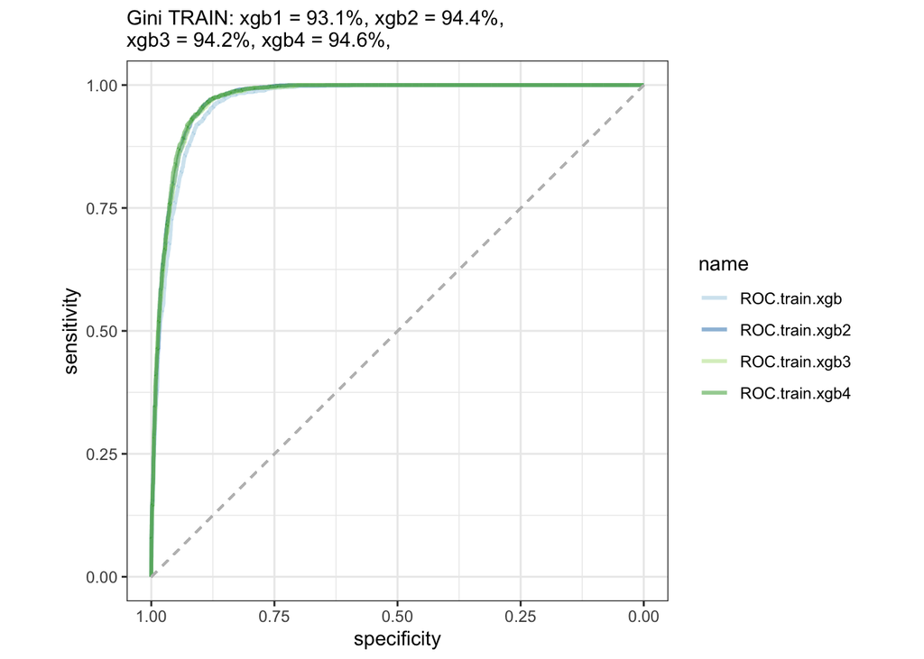

```r
list(
  ROC.train.xgb  = ROC.train.xgb,
  ROC.train.xgb2 = ROC.train.xgb2,
  ROC.train.xgb3 = ROC.train.xgb3,
  ROC.train.xgb4 = ROC.train.xgb4
) %>%
  pROC::ggroc(alpha = 0.5, linetype = 1, size = 1) +
  geom_segment(aes(x = 1, xend = 0, y = 0, yend = 1),
               color = "grey",
               linetype = "dashed") +
  labs(subtitle = paste0("Gini TRAIN: ",
                         "xgb1 = ",
                         round(100 * (2 * auc(ROC.train.xgb) - 1), 1), "%, ",
                         "xgb2 = ",
                         round(100 * (2 * auc(ROC.train.xgb2) - 1), 1), "%, ",
                         "\nxgb3 = ",
                         round(100 * (2 * auc(ROC.train.xgb3) - 1), 1), "%, ",
                         "xgb4 = ",
                         round(100 * (2 * auc(ROC.train.xgb4) - 1), 1), "%, ")) +
  theme_bw() + coord_fixed() +
  scale_color_brewer(palette = "Paired")
```

**All models had quite similar results with last model(xgb4) having higher number of trees(300) and lower learning rate of 0.08 performing better with a higher GINI index of 94.6%**

#### Let us compare the models estimated so far on the validation dataset **

```r
ROC.val.xgb  <- pROC::roc(google_store_data.val$addedToCart,
                           predict(google_store_data.xgb, google_store_data.val,
                                   type = "prob", n.trees = 500)[, "Yes"])
ROC.val.xgb2  <- pROC::roc(google_store_data.val$addedToCart,
                           predict(google_store_data.xgb2, google_store_data.val,
                                   type = "prob", n.trees = 500)[, "Yes"])
ROC.val.xgb3  <- pROC::roc(google_store_data.val$addedToCart,
                           predict(google_store_data.xgb3, google_store_data.val,
                                   type = "prob", n.trees = 500)[, "Yes"])
ROC.val.xgb4  <- pROC::roc(google_store_data.val$addedToCart,
                           predict(google_store_data.xgb4, google_store_data.val,
                                   type = "prob", n.trees = 500)[, "Yes"])
```

**Plotting ROC Curves**

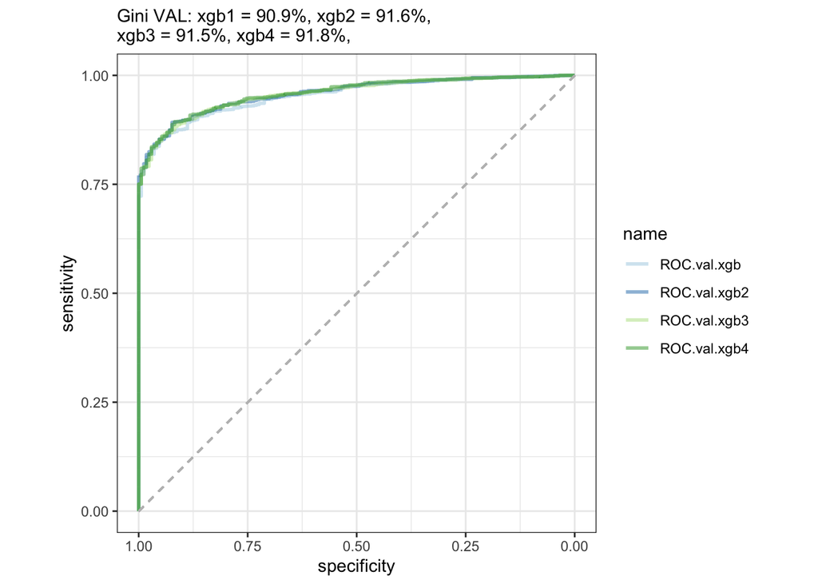

```r
list(
  ROC.val.xgb  = ROC.val.xgb,
  ROC.val.xgb2 = ROC.val.xgb2,
  ROC.val.xgb3 = ROC.val.xgb3,
  ROC.val.xgb4 = ROC.val.xgb4
) %>%
  pROC::ggroc(alpha = 0.5, linetype = 1, size = 1) +
  geom_segment(aes(x = 1, xend = 0, y = 0, yend = 1),
               color = "grey",
               linetype = "dashed") +
  labs(subtitle = paste0("Gini VAL: ",
                         "xgb1 = ",
                         round(100 * (2 * auc(ROC.val.xgb) - 1), 1), "%, ",
                         "xgb2 = ",
                         round(100 * (2 * auc(ROC.val.xgb2) - 1), 1), "%, ",
                         "\nxgb3 = ",
                         round(100 * (2 * auc(ROC.val.xgb3) - 1), 1), "%, ",
                         "xgb4 = ",
                         round(100 * (2 * auc(ROC.val.xgb4) - 1), 1), "%, ")) +
  theme_bw() + coord_fixed() +
  scale_color_brewer(palette = "Paired")
```

**The performance on validation data is not so distant from that of train data with xgb4 having a higher GINI index of 91.8%**

#### Let us compare best models estimated so far on the test dataset

**For final testing, we used resampled data**

```r
test.tree4.pred <- predict(google_store_data.tree.4,
                            google_store_data.test)
test.tree4.ROC  <- roc(
  as.numeric(google_store_data.test$addedToCart == "Yes"), test.tree4.pred[, 1])
test.xgb4.ROC  <- pROC::roc(google_store_data.test$addedToCart,
                           predict(google_store_data.xgb4, google_store_data.test,
                                   type = "prob", n.trees = 500)[, "Yes"])
```

**Plotting ROC Curves**

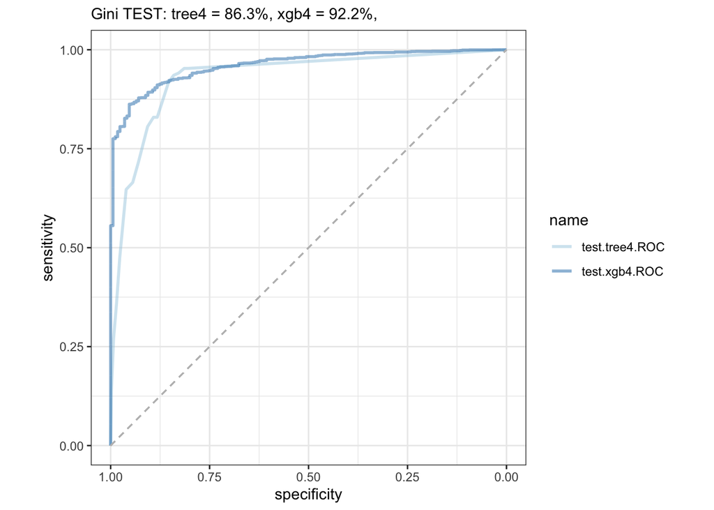

```r
list(
  test.tree4.ROC  = test.tree4.ROC,
  test.xgb4.ROC = test.xgb4.ROC
) %>%
  pROC::ggroc(alpha = 0.5, linetype = 1, size = 1) +
  geom_segment(aes(x = 1, xend = 0, y = 0, yend = 1),
               color = "grey",
               linetype = "dashed") +
  labs(subtitle = paste0("Gini TEST: ",
                         "tree4 = ",
                         round(100 * (2 * auc(test.tree4.ROC) - 1), 1), "%, ",
                         "xgb4 = ",
                         round(100 * (2 * auc(test.xgb4.ROC) - 1), 1), "%, ")) +
  theme_bw() + coord_fixed() +
  scale_color_brewer(palette = "Paired")
```

**On testing data XGBoost had a higher performance of 92%

# Conclusion

We built Decision tree models and XGBoost models to predict whether each session will result in the visitor performing an action to add an item to the cart.

FullVisitorId, date and totalVisits were excluded for model building. Day and month were engineered from the date column to improve performance of ML models and they were part of the top 10 variables that contributed to the model performance

GINI index was used to evaluate the models. XGBoost was chosen as the final model as it had better performance on validation(91.8%) and test datasets(92.2%) compared to Decision Trees.